# IFN702: Educational Data Mining project

###### version 1.0 — Zhiying Zhou: 9835580

# Introduction

This study will process, exploration, analyze and predict Student’s academic performance based on a XAPI Educational Mining Datasets.

The XAPI Educational Mining Datasets is download from the Kaggle website. It was collected from an e-Learning system called Kalboard 360 using Experience API Web service (XAPI).

The datasets consist of 480 student records and 16 features. The features are classified into three major categories: 1. Demographic features such as gender, grade levels, topic and nationality. 2. Academic background features such as educational stage, grade Level and section. 3. Behavioral features such as raised hand on class, opening resources, answering survey by parents, and school satisfaction.

Attributes 1 Gender - student’s gender (nominal: ‘Male’ or ‘Female’) 2 Nationality- student’s nationality (nominal:‘Kuwait’,‘Lebanon’,‘Egypt’,‘SaudiArabia’,‘USA’,‘Jordan’,‘Venezuela’,‘Iran’,‘Tunis’,‘Morocco’,‘Syria’,‘Palestine’,‘Iraq’,‘Lybia’) 3 Place of birth- student’s Place of birth (nominal:‘Kuwait’,‘Lebanon’,‘Egypt’,‘SaudiArabia’,‘USA’,‘Jordan’,‘Venezuela’,‘Iran’,‘Tunis’,‘Morocco’,‘Syria’,‘Palestine’,‘Iraq’,‘Lybia’) 4 Educational Stages- educational level student belongs (nominal: ‘lowerlevel’,‘MiddleSchool’,‘HighSchool’) 5 Grade Levels- grade student belongs (nominal: ‘G-01’, ‘G-02’, ‘G-03’, ‘G-04’, ‘G-05’, ‘G-06’, ‘G-07’, ‘G-08’, ‘G-09’, ‘G-10’, ‘G-11’, ‘G-12’) 6 Section ID- classroom student belongs (nominal:‘A’,‘B’,‘C’) 7 Topic- course topic (nominal:‘English’,‘Spanish’, ‘French’,‘Arabic’,‘IT’,‘Math’,‘Chemistry’, ‘Biology’, ‘Science’,‘History’,‘Quran’,‘Geology’) 8 Semester- school year semester (nominal:‘First’,‘Second’) 9 Parent responsible for student (nominal:‘mom’,‘father’) 10 Raised hand- how many times the student raises his/her hand on classroom (numeric:0-100) 11- Visited resources- how many times the student visits a course content(numeric:0-100) 12 Viewing announcements-how many times the student checks the new announcements(numeric:0-100) 13 Discussion groups- how many times the student participate on discussion groups (numeric:0-100) 14 Parent Answering Survey- parent answered the surveys which are provided from school or not (nominal:‘Yes’,‘No’) 15 Parent School Satisfaction- the Degree of parent satisfaction from school(nominal:‘Yes’,‘No’) 16 Student Absence Days-the number of absence days for each student (nominal: above-7, under-7)

The students are classified into three numerical intervals based on their total grade/mark:

Low-Level: interval includes values from 0 to 69, Middle-Level: interval includes values from 70 to 89, High-Level: interval includes values from 90-100.

We will use R Studio to analyze this datasets in R programming language, and aim to achieve the following targets:

1. Pre-process of the datasets. Clean the dataset, remove the useless columns or rows; and
2. Explore the datasets. Explore the distribution of the datasets in different features: gender, nationality, grade, topic, parental satisfaction etc. (like girls raises more hand, more discussions in high school etc.); and
3. Find underlying relationships. Like parent who are not satisfied and not answer survey, connection with study activity and performance (raising hand, discussion, absence, parental satisfaction, answering survey etc.); and
4. Build prediction model, like decision tree or regression model to predict the student’s academic performance.
5. Evaluate the predictive results of models and improve the models by comparing the accuracy.

# Task 1. Exploration of the students’ academic performance datasets

```r
# install libraries
library(ggplot2)
library(reshape2)
library(partykit)
library(caret)
library(e1071)
library(randomForest)
library(dplyr)
```

# Task 1.1. Preprocess the data set:

```r
# Import XAPI Educational data sets
E <- read.csv("data/xAPI-Edu-Data.csv")
```

```r
str(E)
```

```
'data.frame':   480 obs. of  17 variables:
 $ gender                  : Factor w/ 2 levels "F","M": 2 2 2 2 2 1 2 2 1 1 ...
 $ NationalITy             : Factor w/ 14 levels "Egypt","Iran",..: 5 5 5 5 5 5 5 5 5 5 ...
 $ PlaceofBirth            : Factor w/ 14 levels "Egypt","Iran",..: 5 5 5 5 5 5 5 5 5 5 ...
 $ StageID                 : Factor w/ 3 levels "HighSchool","lowerlevel",..: 2 2 2 2 2 2 3 3 3 3 ...
 $ GradeID                 : Factor w/ 10 levels "G-02","G-04",..: 2 2 2 2 2 2 5 5 5 5 ...
 $ SectionID               : Factor w/ 3 levels "A","B","C": 1 1 1 1 1 1 1 1 1 2 ...
 $ Topic                   : Factor w/ 12 levels "Arabic","Biology",..: 8 8 8 8 8 8 9 9 9 8 ...
 $ Semester                : Factor w/ 2 levels "F","S": 1 1 1 1 1 1 1 1 1 1 ...
 $ Relation                : Factor w/ 2 levels "Father","Mum": 1 1 1 1 1 1 1 1 1 1 ...
 $ raisedhands             : int  15 20 10 30 40 42 35 50 12 70 ...
 $ VisITedResources        : int  16 20 7 25 50 30 12 10 21 80 ...
 $ AnnouncementsView       : int  2 3 0 5 12 13 0 15 16 25 ...
 $ Discussion              : int  20 25 30 35 50 70 17 22 50 70 ...
 $ ParentAnsweringSurvey   : Factor w/ 2 levels "No","Yes": 2 2 1 1 1 2 1 2 2 2 ...
 $ ParentschoolSatisfaction: Factor w/ 2 levels "Bad","Good": 2 2 1 1 1 1 1 2 2 2 ...
 $ StudentAbsenceDays      : Factor w/ 2 levels "Above-7","Under-7": 2 2 1 1 1 1 1 2 2 2 ...
 $ Class                   : Factor w/ 3 levels "H","L","M": 3 3 2 2 3 3 2 3 3 3 ...
```

```r
summary(E)
```

```
 gender     NationalITy       PlaceofBirth         StageID       GradeID    SectionID     Topic     Semester
 F:175   KW       :179   KuwaIT     :180   HighSchool  : 33   G-02   :147   A:283     IT     : 95   F:245
 M:305   Jordan   :172   Jordan     :176   lowerlevel  :199   G-08   :116   B:167     French : 65   S:235
         Palestine: 28   Iraq       : 22   MiddleSchool:248   G-07   :101   C: 30     Arabic : 59
         Iraq     : 22   lebanon    : 19                      G-04   : 48             Science: 51
         lebanon  : 17   SaudiArabia: 16                      G-06   : 32             English: 45
         Tunis    : 12   USA        : 16                      G-11   : 13             Biology: 30
         (Other)  : 50   (Other)    : 51                      (Other): 23             (Other):135
   Relation    raisedhands     VisITedResources AnnouncementsView   Discussion    ParentAnsweringSurvey
 Father:283   Min.   :  0.00   Min.   : 0.0     Min.   : 0.00     Min.   : 1.00   No :210
 Mum   :197   1st Qu.: 15.75   1st Qu.:20.0     1st Qu.:14.00     1st Qu.:20.00   Yes:270
              Median : 50.00   Median :65.0     Median :33.00     Median :39.00
              Mean   : 46.77   Mean   :54.8     Mean   :37.92     Mean   :43.28
              3rd Qu.: 75.00   3rd Qu.:84.0     3rd Qu.:58.00     3rd Qu.:70.00
              Max.   :100.00   Max.   :99.0     Max.   :98.00     Max.   :99.00

 ParentschoolSatisfaction StudentAbsenceDays Class
 Bad :188                 Above-7:191        H:142
 Good:292                 Under-7:289        L:127
                                             M:211
```

```r
#Reorder the "Class"" column of the data set, make the sequence of "Class" to be "H","M","L" instead of "H","L","M".
E$Class = factor(E$Class, levels=c("H","M","L"), labels=c("H","M","L"))
#Reorder the "StageID" column of the data set, make the sequence of "StageID" to be "HighSchool","MiddleSchool","Lowerlevel" instead of "HighSchool","lowerlevel","MiddleSchool".
E$StageID = factor(E$StageID, levels=c("HighSchool","MiddleSchool","lowerlevel"), labels=c("HighSchool","MiddleSchool","Lowerlevel"))
```

# Task 1.2. Bar plots of classification values distribution:

# Gender distribution:

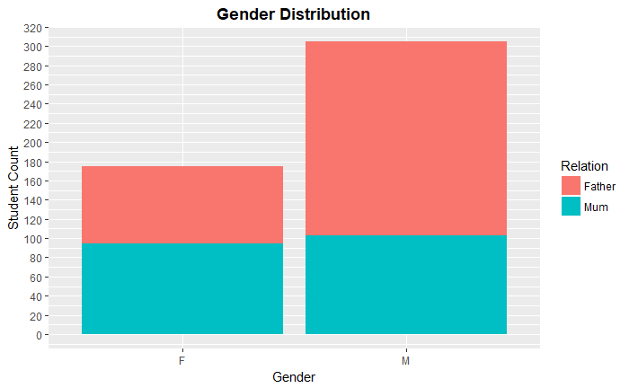

```r
ggplot(data = E, aes(x = gender, fill = Relation)) + geom_bar() +
    labs(x = "Gender", y = "Student Count")+ ggtitle(label = "Gender Distribution")+theme(plot.title = element_text(hjust = 0.5, lineheight = 0.8, face = "bold"))+ scale_y_continuous(breaks = seq(0,320,20))
```

# There are nearly 175 girls and 305 boys in this data set. The number of girls who have mom as guardian nearly the same as having father as guardian, whereas most boys have father as guardians.

```r
ggplot(data = E, aes(x = gender, fill = ParentAnsweringSurvey)) + geom_bar() +
    labs(x = "Gender", y = "Student Count") + ggtitle(label = "Gender Distribution")+theme(plot.title = element_text(hjust = 0.5, lineheight = 0.8, face = "bold"))
```

[output not shown]

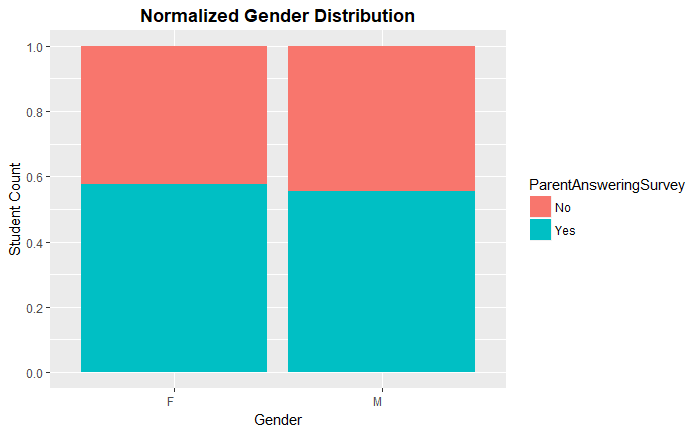

```r
 ESummary = E %>%
 # Get the counts
 group_by(gender, ParentAnsweringSurvey) %>%
 summarise(count = n()) %>%
# Get labels and position of labels
 group_by(gender) %>%
 mutate(Percent = paste0(sprintf("%.1f", count/sum(count) * 100),"%"))
 ggplot(ESummary, aes(x = gender, y = count)) +
 geom_bar(aes(fill = ParentAnsweringSurvey), stat ="identity", position = 'fill')+ labs(x = "Gender", y = "Student Count")+ ggtitle(label = "Normalized Gender Distribution")+theme_grey()+theme(plot.title = element_text(hjust = 0.5, lineheight = 0.8, face = "bold"))+theme(axis.text.x = element_text(angle=0, hjust=1))+ scale_y_continuous(breaks = seq(0,1,0.2))
```

# The rates of parent answering survey are nearly the same between girls and boys, which are both under 60%.

```r
ggplot(data = E, aes(x = gender, fill = ParentschoolSatisfaction)) + geom_bar() +
    labs(x = "Gender", y = "Student Count")+ ggtitle(label = "Gender Distribution")+theme(plot.title = element_text(hjust = 0.5, lineheight = 0.8, face = "bold"))
```

[output not shown]

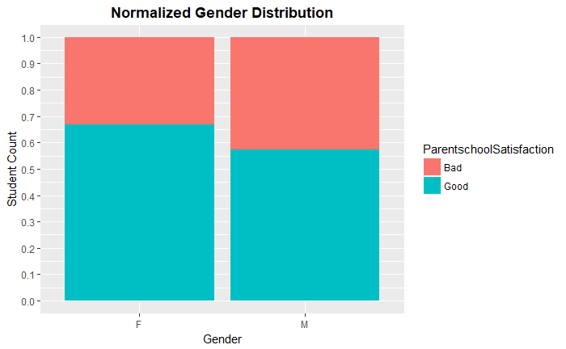

```r
 ESummary = E %>%
 # Get the counts
 group_by(gender, ParentschoolSatisfaction) %>%
 summarise(count = n()) %>%
# Get labels and position of labels
 group_by(gender) %>%
 mutate(Percent = paste0(sprintf("%.1f", count/sum(count) * 100),"%"))
 ggplot(ESummary, aes(x = gender, y = count)) +
 geom_bar(aes(fill = ParentschoolSatisfaction), stat ="identity", position = 'fill')+ labs(x = "Gender", y = "Student Count")+ ggtitle(label = "Normalized Gender Distribution")+theme_grey()+theme(plot.title = element_text(hjust = 0.5, lineheight = 0.8, face = "bold"))+ scale_y_continuous(breaks = seq(0,1,0.1))
```

# Girls’ parents has higher school satisfaction than boys. Girls have higher rate(with about 67%) of parent school satisfaction in good than boys(with about 57%).

```r
ggplot(data = E, aes(x = gender, fill = StudentAbsenceDays)) + geom_bar() +
    labs(x = "Gender", y = "Student Count")+ ggtitle(label = "Gender Distribution")+theme(plot.title = element_text(hjust = 0.5, lineheight = 0.8, face = "bold"))
```

[output not shown]

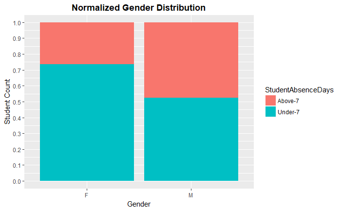

```r
 ESummary = E %>%
 # Get the counts
 group_by(gender, StudentAbsenceDays) %>%
 summarise(count = n()) %>%
# Get labels and position of labels
 group_by(gender) %>%
 mutate(Percent = paste0(sprintf("%.1f", count/sum(count) * 100),"%"))
 ggplot(ESummary, aes(x = gender, y = count)) +
 geom_bar(aes(fill = StudentAbsenceDays), stat ="identity", position = 'fill')+ labs(x = "Gender", y = "Student Count")+ ggtitle(label = "Normalized Gender Distribution")+theme_grey()+theme(plot.title = element_text(hjust = 0.5, lineheight = 0.8, face = "bold"))+ scale_y_continuous(breaks = seq(0,1,0.1))
```

# Boys has higher rate of above 7 absence days.

```r
ggplot(data = E, aes(x = gender, fill = Class)) + geom_bar() +
    labs(x = "Gender", y = "Student Count")  + ggtitle(label = "Gender Distribution")+theme(plot.title = element_text(hjust = 0.5, lineheight = 0.8, face = "bold"))
```

[output not shown]

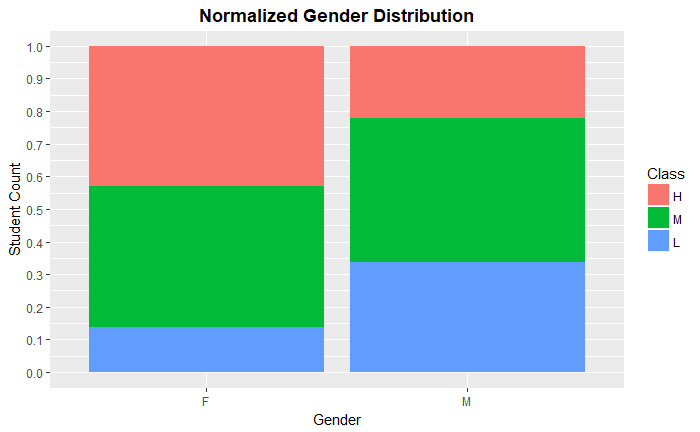

```r
 ESummary = E %>%
 # Get the counts
 group_by(gender, Class) %>%
 summarise(count = n()) %>%
# Get labels and position of labels
 group_by(gender) %>%
 mutate(Percent = paste0(sprintf("%.1f", count/sum(count) * 100),"%"))
 ggplot(ESummary, aes(x = gender, y = count)) +
 geom_bar(aes(fill = Class), stat ="identity", position = 'fill')+ labs(x = "Gender", y = "Student Count")+ ggtitle(label = "Normalized Gender Distribution")+theme_grey()+theme(plot.title = element_text(hjust = 0.5, lineheight = 0.8, face = "bold"))+ scale_y_continuous(breaks = seq(0,1,0.1))
```

# Girls have higher rate (over 40%) of people with high academic performance, whereas a small rate of boys (about 20%) have high performance. The rate of median class is almost the same both for girls and boys, which are both about 40%. About 35% rate of boys have low performance, whereas the rate of low class is very low among girls.

# Place of Birth distribution:

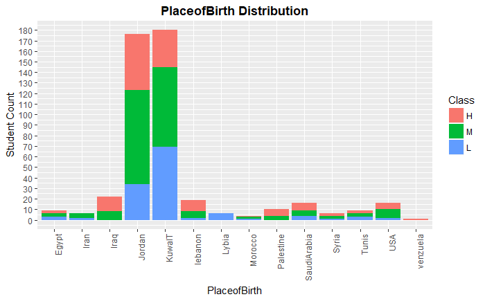

```r
ggplot(data = E, aes(x = PlaceofBirth, fill = Class)) + geom_bar() +
    labs(x = "PlaceofBirth", y = "Student Count") + ggtitle(label = "PlaceofBirth Distribution")+theme(plot.title = element_text(hjust = 0.5, lineheight = 0.8, face = "bold"))+theme(axis.text.x = element_text(angle=90, hjust=1))+ scale_y_continuous(breaks = seq(0,200,10))
```

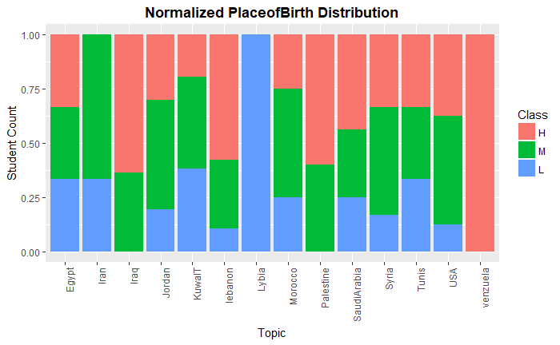

```r
 ESummary = E %>%
 # Get the counts
 group_by(PlaceofBirth, Class) %>%
 summarise(count = n()) %>%
# Get labels and position of labels
 group_by(PlaceofBirth) %>%
 mutate(Percent = paste0(sprintf("%.1f", count/sum(count) * 100),"%"))
 ggplot(ESummary, aes(x = PlaceofBirth, y = count)) +
 geom_bar(aes(fill = Class), stat ="identity", position = 'fill')+ labs(x = "Topic", y = "Student Count")+ ggtitle(label = "Normalized PlaceofBirth Distribution")+theme_grey()+theme(plot.title = element_text(hjust = 0.5, lineheight = 0.8, face = "bold"))+theme(axis.text.x = element_text(angle=90, hjust=1))
```

# Most of the students were born in Jordan and Kuwait. Venzuela has only one student.

# Iraq, Lebanon, Saudiarabia, Palestine, USA and Venzuela have higher rate of student with high class, whereas Kuwait and Lybia have higher rate of students with low class.

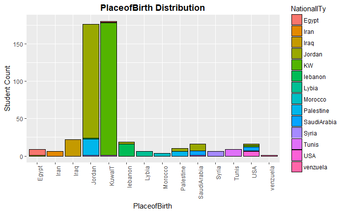

```r
ggplot(data = E, aes(x = PlaceofBirth, fill = NationalITy)) + geom_bar(colour= "Black") +
    labs(x = "PlaceofBirth", y = "Student Count")+ ggtitle(label = "PlaceofBirth Distribution")+theme(plot.title = element_text(hjust = 0.5, lineheight = 0.8, face = "bold")) +theme(axis.text.x = element_text(angle=90, hjust=1))
```

# Most of the students who were born in these countries of Egypt, Iran, Iraq, Kuwait, Lebanon, Lybia, Morocco, Syria, Tunis and Venzuela have the same nationality as the place of birth. some of the students who were born in Jordan have the nationality of Palestine. The students who were born in USA have diversity of nationality. Half of the students who were born in Saudiarabia have the nationality of Jordan.

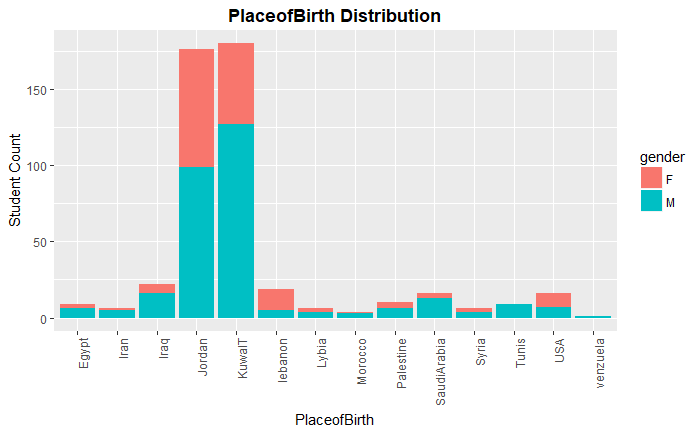

```r
ggplot(data = E, aes(x = PlaceofBirth, fill = gender)) + geom_bar() +
    labs(x = "PlaceofBirth", y = "Student Count")+ ggtitle(label = "PlaceofBirth Distribution")+theme(plot.title = element_text(hjust = 0.5, lineheight = 0.8, face = "bold")) +theme(axis.text.x = element_text(angle=90, hjust=1))
```

# Lebanon has most rate of girls, half of the USA students are girls. Girls are less than boys in the other areas.

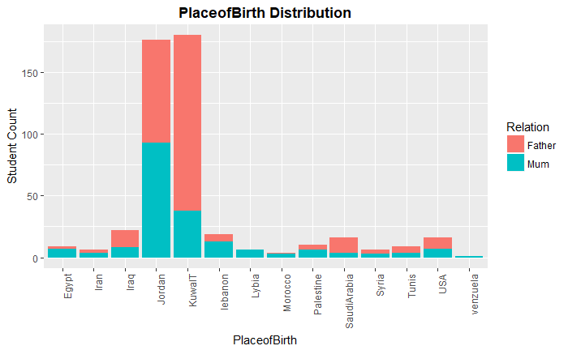

```r
ggplot(data = E, aes(x = PlaceofBirth, fill = Relation)) + geom_bar() +
    labs(x = "PlaceofBirth", y = "Student Count")+ ggtitle(label = "PlaceofBirth Distribution")+theme(plot.title = element_text(hjust = 0.5, lineheight = 0.8, face = "bold")) +theme(axis.text.x = element_text(angle=90, hjust=1))
```

# Based on the place of birth, most fathers are responsible for students in some countries like: Kuwait, Iraq, Saudiarabia. Most mothers are responsible for students’ study in these areas like: Egypt, Iran, Jordan, Lebanon, LYbia, Morocco, Palestine and Venzuela.

# Nationality distribution:

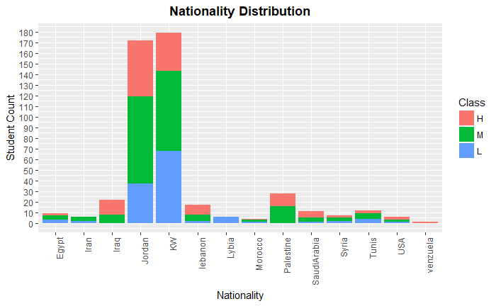

```r
ggplot(data = E, aes(x = NationalITy, fill = Class)) + geom_bar() +
    labs(x = "Nationality", y = "Student Count")+ ggtitle(label = "Nationality Distribution")+theme(plot.title = element_text(hjust = 0.5, lineheight = 0.8, face = "bold"))+theme(axis.text.x = element_text(angle=90, hjust=1))+ scale_y_continuous(breaks = seq(0,200,10))
```

# Jordan and KW(KuwaIT) has highest number of students. Venzuela has only one student.

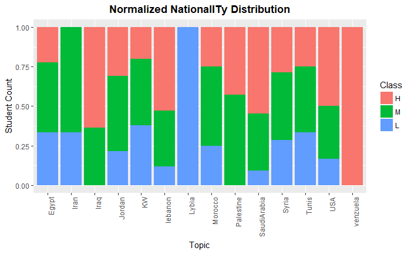

```r
 ESummary = E %>%
 # Get the counts
 group_by(NationalITy, Class) %>%
 summarise(count = n()) %>%
# Get labels and position of labels
 group_by(NationalITy) %>%
 mutate(Percent = paste0(sprintf("%.1f", count/sum(count) * 100),"%"))
 ggplot(ESummary, aes(x = NationalITy, y = count)) +
 geom_bar(aes(fill = Class), stat ="identity", position = 'fill')+ labs(x = "Topic", y = "Student Count")+ ggtitle(label = "Normalized NationalITy Distribution")+theme_grey()+theme(plot.title = element_text(hjust = 0.5, lineheight = 0.8, face = "bold"))+theme(axis.text.x = element_text(angle=90, hjust=1))
```

# Iraq, Lebanon, Saudiarabia, Palestine, USA and Venzuela have higher rate of student with high class, whereas Kuwait and Lybia have higher rate of students with low class.

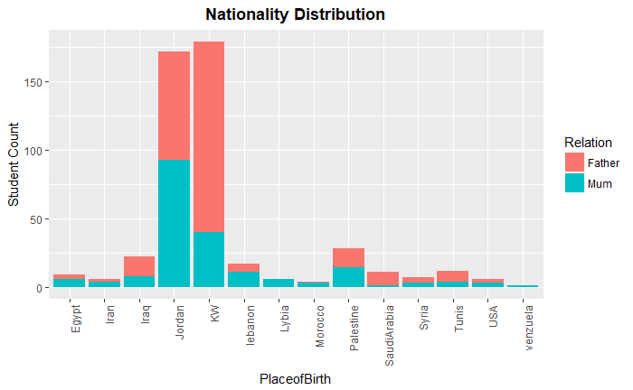

```r
ggplot(data = E, aes(x = NationalITy, fill = Relation)) + geom_bar() +
    labs(x = "PlaceofBirth", y = "Student Count")+ ggtitle(label = "Nationality Distribution")+theme(plot.title = element_text(hjust = 0.5, lineheight = 0.8, face = "bold")) +theme(axis.text.x = element_text(angle=90, hjust=1))
```